# R Notebook

# Platzi - Course Fundamentals of R

```r
summary(mtcars)
```

```
      mpg             cyl             disp             hp             drat             wt             qsec             vs               am
 Min.   :10.40   Min.   :4.000   Min.   : 71.1   Min.   : 52.0   Min.   :2.760   Min.   :1.513   Min.   :14.50   Min.   :0.0000   Min.   :0.0000
 1st Qu.:15.43   1st Qu.:4.000   1st Qu.:120.8   1st Qu.: 96.5   1st Qu.:3.080   1st Qu.:2.581   1st Qu.:16.89   1st Qu.:0.0000   1st Qu.:0.0000
 Median :19.20   Median :6.000   Median :196.3   Median :123.0   Median :3.695   Median :3.325   Median :17.71   Median :0.0000   Median :0.0000
 Mean   :20.09   Mean   :6.188   Mean   :230.7   Mean   :146.7   Mean   :3.597   Mean   :3.217   Mean   :17.85   Mean   :0.4375   Mean   :0.4062
 3rd Qu.:22.80   3rd Qu.:8.000   3rd Qu.:326.0   3rd Qu.:180.0   3rd Qu.:3.920   3rd Qu.:3.610   3rd Qu.:18.90   3rd Qu.:1.0000   3rd Qu.:1.0000
 Max.   :33.90   Max.   :8.000   Max.   :472.0   Max.   :335.0   Max.   :4.930   Max.   :5.424   Max.   :22.90   Max.   :1.0000   Max.   :1.0000
      gear            carb
 Min.   :3.000   Min.   :1.000
 1st Qu.:3.000   1st Qu.:2.000
 Median :4.000   Median :2.000
 Mean   :3.688   Mean   :2.812
 3rd Qu.:4.000   3rd Qu.:4.000
 Max.   :5.000   Max.   :8.000
```

```r
mtcars
```

|  | mpg | cyl | disp | hp | drat | wt | qsec | vs | am | gear | carb |
| --- | --- | --- | --- | --- | --- | --- | --- | --- | --- | --- | --- |
| Mazda RX4 | 21.0 | 6 | 160.0 | 110 | 3.90 | 2.620 | 16.46 | 0 | 1 | 4 | 4 |
| Mazda RX4 Wag | 21.0 | 6 | 160.0 | 110 | 3.90 | 2.875 | 17.02 | 0 | 1 | 4 | 4 |
| Datsun 710 | 22.8 | 4 | 108.0 | 93 | 3.85 | 2.320 | 18.61 | 1 | 1 | 4 | 1 |
| Hornet 4 Drive | 21.4 | 6 | 258.0 | 110 | 3.08 | 3.215 | 19.44 | 1 | 0 | 3 | 1 |
| Hornet Sportabout | 18.7 | 8 | 360.0 | 175 | 3.15 | 3.440 | 17.02 | 0 | 0 | 3 | 2 |
| Valiant | 18.1 | 6 | 225.0 | 105 | 2.76 | 3.460 | 20.22 | 1 | 0 | 3 | 1 |
| Duster 360 | 14.3 | 8 | 360.0 | 245 | 3.21 | 3.570 | 15.84 | 0 | 0 | 3 | 4 |
| Merc 240D | 24.4 | 4 | 146.7 | 62 | 3.69 | 3.190 | 20.00 | 1 | 0 | 4 | 2 |
| Merc 230 | 22.8 | 4 | 140.8 | 95 | 3.92 | 3.150 | 22.90 | 1 | 0 | 4 | 2 |
| Merc 280 | 19.2 | 6 | 167.6 | 123 | 3.92 | 3.440 | 18.30 | 1 | 0 | 4 | 4 |

[output cut: 22 more lines]

```r
wt_new <- (mtcars$wt*1000)/2
wt_new
```

```
 [1] 1310.0 1437.5 1160.0 1607.5 1720.0 1730.0 1785.0 1595.0 1575.0 1720.0 1720.0 2035.0 1865.0 1890.0 2625.0 2712.0 2672.5 1100.0  807.5  917.5 1232.5
[22] 1760.0 1717.5 1920.0 1922.5  967.5 1070.0  756.5 1585.0 1385.0 1785.0 1390.0
```

Transform

```r
mtcars_new <- transform(mtcars, wt = wt_new)

mtcars_new
```

|  | mpg | cyl | disp | hp | drat | wt | qsec | vs | am | gear | carb |
| --- | --- | --- | --- | --- | --- | --- | --- | --- | --- | --- | --- |
| Mazda RX4 | 21.0 | 6 | 160.0 | 110 | 3.90 | 1310.0 | 16.46 | 0 | 1 | 4 | 4 |
| Mazda RX4 Wag | 21.0 | 6 | 160.0 | 110 | 3.90 | 1437.5 | 17.02 | 0 | 1 | 4 | 4 |
| Datsun 710 | 22.8 | 4 | 108.0 | 93 | 3.85 | 1160.0 | 18.61 | 1 | 1 | 4 | 1 |
| Hornet 4 Drive | 21.4 | 6 | 258.0 | 110 | 3.08 | 1607.5 | 19.44 | 1 | 0 | 3 | 1 |
| Hornet Sportabout | 18.7 | 8 | 360.0 | 175 | 3.15 | 1720.0 | 17.02 | 0 | 0 | 3 | 2 |
| Valiant | 18.1 | 6 | 225.0 | 105 | 2.76 | 1730.0 | 20.22 | 1 | 0 | 3 | 1 |
| Duster 360 | 14.3 | 8 | 360.0 | 245 | 3.21 | 1785.0 | 15.84 | 0 | 0 | 3 | 4 |
| Merc 240D | 24.4 | 4 | 146.7 | 62 | 3.69 | 1595.0 | 20.00 | 1 | 0 | 4 | 2 |
| Merc 230 | 22.8 | 4 | 140.8 | 95 | 3.92 | 1575.0 | 22.90 | 1 | 0 | 4 | 2 |
| Merc 280 | 19.2 | 6 | 167.6 | 123 | 3.92 | 1720.0 | 18.30 | 1 | 0 | 4 | 4 |

[output cut: 22 more lines]

Load the Orangeec.csv

```r
> library(readr)
> orangeec <- read_csv("Orange-Economy-master/orangeec.csv")
```

Summary

```r
summary(orangeec)
```

[output not shown]

```r
str(orangeec)
```

```
spec_tbl_df [17 × 13] (S3: spec_tbl_df/tbl_df/tbl/data.frame)
 $ Country                          : chr [1:17] "Argentina" "Belize" "Bolivia" "Brazil" ...
 $ GDP PC                           : num [1:17] 20900 8300 7500 15600 24500 14500 16900 11500 8900 8100 ...
 $ GDP US bill                      : num [1:17] 6.38e+02 1.85e+03 3.71e+01 2.06e+06 2.77e+02 ...
 $ GDP Growth %                     : num [1:17] 2.9 0.8 4.2 1 1.5 1.8 3.2 2.7 2.4 2.8 ...
 $ Services % GDP                   : num [1:17] 60.9 62.2 50 72.8 64.3 61.4 73.5 56.9 64.9 63.2 ...
 $ Creat Ind % GDP                  : num [1:17] 3.8 NA NA 2.6 2.2 3.3 2 2 NA NA ...
 $ Inflation                        : num [1:17] 25.7 1.1 2.8 3.4 2.2 4.3 1.6 0.4 1 4.4 ...
 $ Unemployment                     : num [1:17] 8.1 10.1 4 11.8 7 10.5 8.1 4.6 7 2.3 ...
 $ % pop below poverty line         : num [1:17] 25.7 41 38.6 4.2 14.4 28 21.7 21.5 32.7 59.3 ...
 $ Internet penetration % population: num [1:17] 93.1 52.3 78.6 70.7 77.5 63.2 86.7 79.9 57.7 42.1 ...
 $ Median age                       : num [1:17] 31.7 22.7 24.3 32 34.4 30 31.3 27.7 27.1 22.1 ...
 $ % pop 25-54                      : num [1:17] 39.4 36.6 37.5 43.9 43.1 ...
 $ Education invest % GDP           : num [1:17] 5.9 7.4 7.3 5.9 4.9 4.5 7.1 5 3.5 2.8 ...
 - attr(*, "spec")=
  .. cols(
  ..   Country = col_character(),
  ..   `GDP PC` = col_double(),
  ..   `GDP US bill` = col_double(),
  ..   `GDP Growth %` = col_double(),
  ..   `Services % GDP` = col_double(),
  ..   `Creat Ind % GDP` = col_double(),
  ..   Inflation = col_double(),
  ..   Unemployment = col_double(),
  ..   `% pop below poverty line` = col_double(),
  ..   `Internet penetration % population` = col_double(),
  ..   `Median age` = col_double(),
  ..   `% pop 25-54` = col_double(),
  ..   `Education invest % GDP` = col_double()
  .. )
```

```r
orangeec
```

| Country | GDP PC | GDP US bill | GDP Growth % | Services % GDP | Creat Ind % GDP | Inflation | Unemployment | % pop below poverty line | Internet penetration % population | Median age | % pop 25-54 | Education invest % GDP |
| --- | --- | --- | --- | --- | --- | --- | --- | --- | --- | --- | --- | --- |
| Argentina | 20900 | 637.7 | 2.9 | 60.9 | 3.8 | 25.7 | 8.1 | 25.7 | 93.1 | 31.7 | 39.38 | 5.9 |
| Belize | 8300 | 1854.0 | 0.8 | 62.2 | NA | 1.1 | 10.1 | 41.0 | 52.3 | 22.7 | 36.62 | 7.4 |
| Bolivia | 7500 | 37.1 | 4.2 | 50.0 | NA | 2.8 | 4.0 | 38.6 | 78.6 | 24.3 | 37.48 | 7.3 |
| Brazil | 15600 | 2055000.0 | 1.0 | 72.8 | 2.6 | 3.4 | 11.8 | 4.2 | 70.7 | 32.0 | 43.86 | 5.9 |
| Chile | 24500 | 277.0 | 1.5 | 64.3 | 2.2 | 2.2 | 7.0 | 14.4 | 77.5 | 34.4 | 43.08 | 4.9 |
| Colombia | 14500 | 309.2 | 1.8 | 61.4 | 3.3 | 4.3 | 10.5 | 28.0 | 63.2 | 30.0 | 41.91 | 4.5 |
| Costa Rica | 16900 | 58.1 | 3.2 | 73.5 | 2.0 | 1.6 | 8.1 | 21.7 | 86.7 | 31.3 | 44.03 | 7.1 |
| Ecuador | 11500 | 102.3 | 2.7 | 56.9 | 2.0 | 0.4 | 4.6 | 21.5 | 79.9 | 27.7 | 39.59 | 5.0 |
| El Salvador | 8900 | 28.0 | 2.4 | 64.9 | NA | 1.0 | 7.0 | 32.7 | 57.7 | 27.1 | 39.23 | 3.5 |
| Guatemala | 8100 | 75.7 | 2.8 | 63.2 | NA | 4.4 | 2.3 | 59.3 | 42.1 | 22.1 | 34.12 | 2.8 |

[output cut: 7 more lines]

## Operator %in% search in dataset

```r
"Ecuador" %in% orangeec$Country
```

```
[1] TRUE
```

## Subset

```r
orangeec_new <- subset(orangeec, `Internet penetration % population` > 80 & `Education invest % GDP` >= 4.5, select = `Creat Ind % GDP`)
```

```r
orangeec_new
```

[output not shown]

```r
library("dplyr")
```

```r
orangeec_rname <- rename(
  orangeec,
  internet_pen_pop = `Internet penetration % population`,
  country = Country,
  gdp_pc = `GDP PC`,
  gdp_us_bill = `GDP US bill`,
  gdp_growt= `GDP Growth %`,
  gdp_us_bill= `GDP US bill`,
  gdp_growth= `GDP Growth %`,
  services_gdp= `Services % GDP`,
  creat_ind_gdp= `Creat Ind % GDP`,
  inflation= `Inflation`,
  unemployement= `Unemployment`,
  pop_below_poverty_line= `% pop below poverty line`,
  median_age = `Median age`,
  pop_age_of_work = `% pop 25-54`,
  edu_invest_gdp= `Education invest % GDP`,
)
```

## Names clear with janitor package

```r
#Clear name with janitor is the best
orangeec_new <- janitor::clean_names(orangeec)
```

```r
names(orangeec_new)
```

```
 [1] "country"                                 "gdp_pc"
 [3] "gdp_us_bill"                             "gdp_growth_percent"
 [5] "services_percent_gdp"                    "creat_ind_percent_gdp"
 [7] "inflation"                               "unemployment"
 [9] "percent_pop_below_poverty_line"          "internet_penetration_percent_population"
[11] "median_age"                              "percent_pop_25_54"
[13] "education_invest_percent_gdp"
```

```r
orangeec_new[orangeec_new$education_invest_percent_gdp >= 6,]
```

| country | gdp_pc | gdp_us_bill | gdp_growth_percent | services_percent_gdp | creat_ind_percent_gdp | inflation | unemployment | percent_pop_below_poverty_line | internet_penetration_percent_population | median_age | percent_pop_25_54 | education_invest_percent_gdp |
| --- | --- | --- | --- | --- | --- | --- | --- | --- | --- | --- | --- | --- |
| Belize | 8300 | 1854.0 | 0.8 | 62.2 | NA | 1.1 | 10.1 | 41.0 | 52.3 | 22.7 | 36.62 | 7.4 |
| Bolivia | 7500 | 37.1 | 4.2 | 50.0 | NA | 2.8 | 4.0 | 38.6 | 78.6 | 24.3 | 37.48 | 7.3 |
| Costa Rica | 16900 | 58.1 | 3.2 | 73.5 | 2 | 1.6 | 8.1 | 21.7 | 86.7 | 31.3 | 44.03 | 7.1 |

```r
orang_row <- orangeec_new %>% mutate(ID = row_number())
orang_row
```

| country | gdp_pc | gdp_us_bill | gdp_growth_percent | services_percent_gdp | creat_ind_percent_gdp | inflation | unemployment | percent_pop_below_poverty_line | internet_penetration_percent_population | median_age | percent_pop_25_54 | education_invest_percent_gdp | ID |
| --- | --- | --- | --- | --- | --- | --- | --- | --- | --- | --- | --- | --- | --- |
| Argentina | 20900 | 637.7 | 2.9 | 60.9 | 3.8 | 25.7 | 8.1 | 25.7 | 93.1 | 31.7 | 39.38 | 5.9 | 1 |
| Belize | 8300 | 1854.0 | 0.8 | 62.2 | NA | 1.1 | 10.1 | 41.0 | 52.3 | 22.7 | 36.62 | 7.4 | 2 |
| Bolivia | 7500 | 37.1 | 4.2 | 50.0 | NA | 2.8 | 4.0 | 38.6 | 78.6 | 24.3 | 37.48 | 7.3 | 3 |
| Brazil | 15600 | 2055000.0 | 1.0 | 72.8 | 2.6 | 3.4 | 11.8 | 4.2 | 70.7 | 32.0 | 43.86 | 5.9 | 4 |
| Chile | 24500 | 277.0 | 1.5 | 64.3 | 2.2 | 2.2 | 7.0 | 14.4 | 77.5 | 34.4 | 43.08 | 4.9 | 5 |
| Colombia | 14500 | 309.2 | 1.8 | 61.4 | 3.3 | 4.3 | 10.5 | 28.0 | 63.2 | 30.0 | 41.91 | 4.5 | 6 |
| Costa Rica | 16900 | 58.1 | 3.2 | 73.5 | 2.0 | 1.6 | 8.1 | 21.7 | 86.7 | 31.3 | 44.03 | 7.1 | 7 |
| Ecuador | 11500 | 102.3 | 2.7 | 56.9 | 2.0 | 0.4 | 4.6 | 21.5 | 79.9 | 27.7 | 39.59 | 5.0 | 8 |
| El Salvador | 8900 | 28.0 | 2.4 | 64.9 | NA | 1.0 | 7.0 | 32.7 | 57.7 | 27.1 | 39.23 | 3.5 | 9 |
| Guatemala | 8100 | 75.7 | 2.8 | 63.2 | NA | 4.4 | 2.3 | 59.3 | 42.1 | 22.1 | 34.12 | 2.8 | 10 |

[output cut: 7 more lines]

```r
orang_row[orangeec_new$education_invest_percent_gdp >= 6,]
```

| country | gdp_pc | gdp_us_bill | gdp_growth_percent | services_percent_gdp | creat_ind_percent_gdp | inflation | unemployment | percent_pop_below_poverty_line | internet_penetration_percent_population | median_age | percent_pop_25_54 | education_invest_percent_gdp | ID |
| --- | --- | --- | --- | --- | --- | --- | --- | --- | --- | --- | --- | --- | --- |
| Belize | 8300 | 1854.0 | 0.8 | 62.2 | NA | 1.1 | 10.1 | 41.0 | 52.3 | 22.7 | 36.62 | 7.4 | 2 |
| Bolivia | 7500 | 37.1 | 4.2 | 50.0 | NA | 2.8 | 4.0 | 38.6 | 78.6 | 24.3 | 37.48 | 7.3 | 3 |
| Costa Rica | 16900 | 58.1 | 3.2 | 73.5 | 2 | 1.6 | 8.1 | 21.7 | 86.7 | 31.3 | 44.03 | 7.1 | 7 |

```r
orang_row[orangeec_new$education_invest_percent_gdp >= 6,"gdp_pc"]
```

| gdp_pc |
| --- |
| 8300 |
| 7500 |
| 16900 |

## Cuarteto de Anscombe

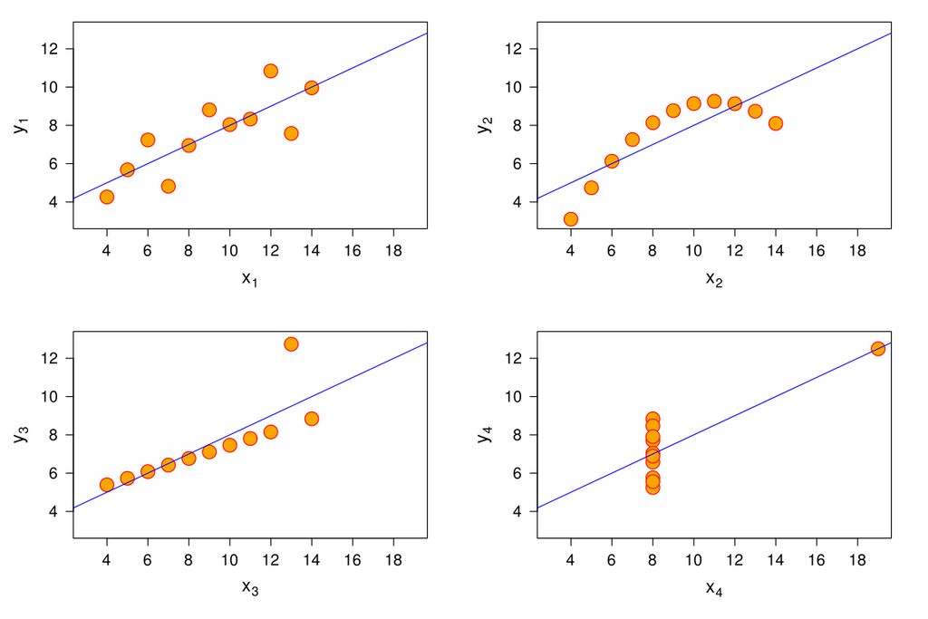

El **cuarteto de Anscombe** comprende cuatro conjuntos de datos que tienen las mismas propiedades estadísticas, pero que evidentemente son distintas al inspeccionar sus gráficos respectivos. … El **cuarteto** es una demostración de la importancia de mirar gráficamente un conjunto de datos antes de analizarlos.

## EDA

- Histograma
- Boxplot
- Scatterplot

## **Box Plot y su interpretación**

Primero los datos se presentan en forma de **TABLA** y **PUNTOS**. Los 197 datos que corresponden a las 197 tiendas evaluadas  
.

**DATOS EN FORMA DE TABLA**

[figure not shown]

Con esta vista no es facil extraer, interpretar, ni describir la informacion del comportamiento de los datos  
.

**DATOS EN FORMA DE PUNTOS**

[figure not shown]

Muchas tiendas con calificaciòn entre 75 y 80  
No hay tiendas por encima de 85 y tampoco por debo de 40  
La informaciòn es limitada  
.

**ENTONCES ORDENAS LOS DATOS DE MENOR < A > MAYOR** 💡  
minimo y maximo

[figure not shown]

La calificaciòn mas baja la tuvo Trujillo 1-PER con 47,8 y la mas alta Callao 2-PER 83,3  
.

[figure not shown]

**LEVANTAS UNA LINEA A 1/4 DE LA LINEA DE DATOS**  
primer cuartil  
Barranquilla 2-COL obtuvo 64,7  
*El 25% de las tiendas evaluadas lograron una calificaciòn inferior a 64,7 o que el 75% de las tiendas lograron una calificaciòn superior a 64,7*

[figure not shown]

.

**LEVANTAS UNA LINEA A 3/4 DE LA LINEA DE DATOS**  
tercer cuartil  
Guayaquil 2-ECU con calificaciòn de 76,7  
Podemos decir que *el 75% de nuestras tiendas lograron una calificaciòn inferior a 76,7 o que el 25% de las tiendas lograron una calificaciòn por encima de 76,7*

[figure not shown]

**LAS 5 CLAVES DE ESTADISTICA DESCRIPTIVA QUE VES EN EL BOX PLOT**

[figure not shown]

## EDA scatterplots

```r
plot(mtcars$mpg ~ mtcars$cyl,
     xlab ='Cilindros', ylab ='millas por galon',
     main='Relacion cilindros y millas por galon')
```

[output not shown]

```r
# EDA scaterplot  mtcars



plot(mtcars$mpg ~ mtcars$hp,
     xlab ='Caballos de fuerza', ylab ='millas por galon',
     main='Relacion Caballos de fuerza y millas por galon')
```

[output not shown]

```r
# EDA scaterplot  orangecc

plot(orangeec_new$unemployment ~ orangeec_new$education_invest_percent_gdp,
     xlab ='Inversion Educacion (%PIB)',ylab ='Desempleo',
     main='Relacion entre Inversion  en educaion y desempleo')
```

[output not shown]

```r
plot(orangeec_new$gdp_pc ~ orangeec_new$creat_ind_percent_gdp,
     xlab ='Aporte economia naranja al (%PIB)',ylab ='Pib percapita',
     main='Relacion economia naranja y PIB per capita')
```

[output not shown]

## EDA histograma

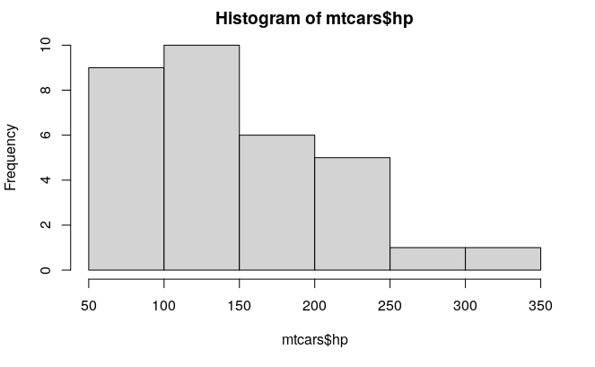

```r
hist(mtcars$hp)
```

```r
# histograsma mtcars qplot
install.packages("ggplot2")
library(ggplot2)
```

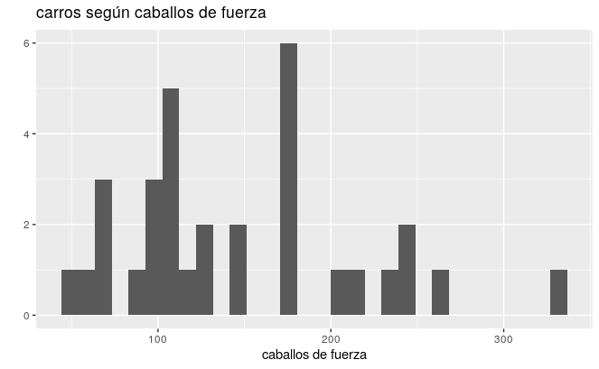

```r
qplot(mtcars$hp,
      geom = "histogram",
      xlab = "caballos de fuerza",
      main = "carros según caballos de fuerza")
```

```r
NA
NA
```

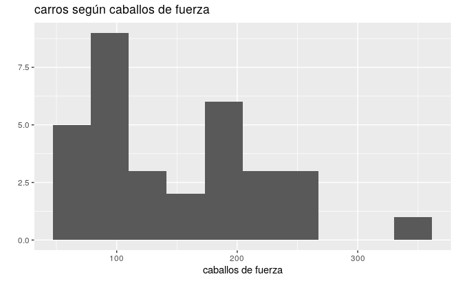

```r
qplot(mtcars$hp,
      geom = "histogram",
      xlab = "caballos de fuerza",
      main = "carros según caballos de fuerza",
      bins = 10
)
```

```r
ggplot(mtcars, aes(x=hp))+
         geom_histogram()+
         labs(x='Caballos de fuerza',
              y='Cantidad de carros',
              title= 'Cabballos de fuerza en carro seleccionados')+
        theme(legend.position = "none")+
        theme(panel.background = element_blank(),
              panel.grid.major = element_blank(),
              panel.grid.minor = element_blank())
```

[output not shown]

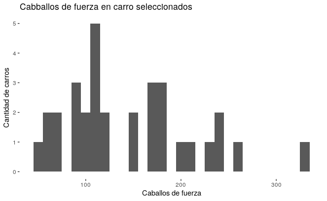

```r
ggplot(mtcars, aes(x=hp))+
  geom_histogram(binwidth = 10)+
  labs(x='Caballos de fuerza',
       y='Cantidad de carros',
       title= 'Cabballos de fuerza en carro seleccionados')+
  theme(legend.position = "none")+
  theme(panel.background = element_blank(),
        panel.grid.major = element_blank(),
        panel.grid.minor = element_blank())
```

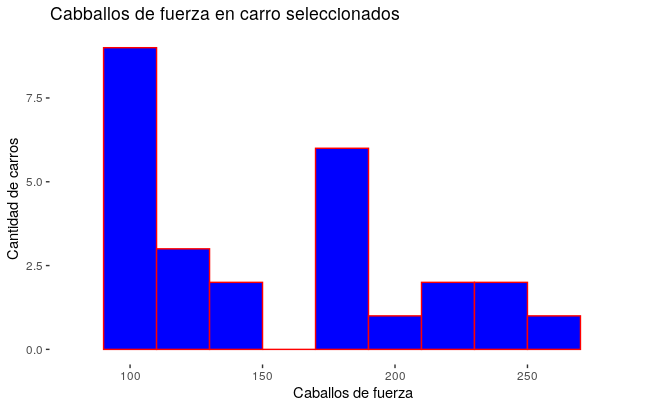

```r
ggplot() + geom_histogram(data=mtcars,
                          aes(x=hp), fill = 'blue', color = 'red',
                          binwidth = 20)+
  labs(x='Caballos de fuerza',
       y='Cantidad de carros',
       title= 'Cabballos de fuerza en carro seleccionados')+
  xlim(c(80,288))+
  theme(legend.position = "none")+
  theme(panel.background = element_blank(),
        panel.grid.major = element_blank(),
        panel.grid.minor = element_blank())
```